# Unsupervised Learning Final Project: Iris Species Clustering Analysis

## Comparative Study of K-Means vs Agglomerative Hierarchical Clustering

A copy of this notebook can be found on GitHub

## Problem Description

### Background

The Iris flower dataset is a classic multivariate dataset introduced by Sir Ronald Fisher in 1936. It consists of 150 samples from three species of Iris flowers (Iris setosa, Iris versicolor, and Iris virginica) with four features measured from each sample: sepal length, sepal width, petal length, and petal width.

This is perhaps the best known database to be found in the pattern recognition literature. Fisher's paper is a classic in the field and is referenced frequently to this day. While one class is linearly separable from the other 2, the latter are NOT linearly separable from each other, making the problem interesting.

### Objectives

This project aims to:

- Apply and compare two fundamental clustering algorithms: K-Means and Agglomerative Hierarchical Clustering
- Evaluate clustering performance using both internal (silhouette score) and external (accuracy, ARI) metrics
- Determine optimal number of clusters using multiple validation techniques
- Compare different linkage methods and metric parameters for Agglomerative Clustering

### Import Necessary Libraries

```python
from itertools import permutations
import numpy as np
import pandas as pd
import matplotlib.pyplot as plt
import seaborn as sns
from sklearn.datasets import load_iris
from sklearn.cluster import KMeans, AgglomerativeClustering
from sklearn.preprocessing import StandardScaler
from sklearn.decomposition import PCA
from sklearn.metrics import silhouette_score, adjusted_rand_score, accuracy_score, confusion_matrix
import scipy.cluster.hierarchy as sch
from scipy import stats

%matplotlib inline
```

### Load and Explore the Dataset

```
Dataset Overview:
Features: ['sepal length (cm)', 'sepal width (cm)', 'petal length (cm)', 'petal width (cm)']
Species: ['setosa', 'versicolor', 'virginica']

Dataframe structure:
<class 'pandas.core.frame.DataFrame'>
RangeIndex: 150 entries, 0 to 149
Data columns (total 6 columns):
 #   Column             Non-Null Count  Dtype
---  ------             --------------  -----
 0   sepal length (cm)  150 non-null    float64
 1   sepal width (cm)   150 non-null    float64
 2   petal length (cm)  150 non-null    float64
 3   petal width (cm)   150 non-null    float64
 4   species            150 non-null    object
 5   true_labels        150 non-null    int64
dtypes: float64(4), int64(1), object(1)
memory usage: 7.2+ KB
```

|  | sepal length (cm) | sepal width (cm) | petal length (cm) | petal width (cm) | species | true_labels |
| --- | --- | --- | --- | --- | --- | --- |
| 0 | 5.1 | 3.5 | 1.4 | 0.2 | setosa | 0 |
| 1 | 4.9 | 3.0 | 1.4 | 0.2 | setosa | 0 |
| 2 | 4.7 | 3.2 | 1.3 | 0.2 | setosa | 0 |
| 3 | 4.6 | 3.1 | 1.5 | 0.2 | setosa | 0 |
| 4 | 5.0 | 3.6 | 1.4 | 0.2 | setosa | 0 |

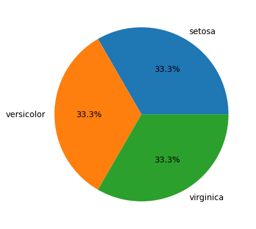

```python
# Load the Iris dataset
iris = load_iris()
X = iris.data
target = iris.target
species_names = iris.target_names

# Create a DataFrame for better visualization
df = pd.DataFrame(X, columns=iris.feature_names)
df['species'] = species_names[target]
df['true_labels'] = target

print("Dataset Overview:")
print("Features:", iris.feature_names)
print("Species:", species_names.tolist())
print("\nDataframe structure:")
df.info()
df.species.value_counts().plot.pie(autopct='%.1f%%', ylabel='')
df.head()
```

### EDA (Exploratory Data Analysis)

```python
# Basic statistics
df[iris.feature_names].describe().round(2)
```

|  | sepal length (cm) | sepal width (cm) | petal length (cm) | petal width (cm) |
| --- | --- | --- | --- | --- |
| count | 150.00 | 150.00 | 150.00 | 150.00 |
| mean | 5.84 | 3.06 | 3.76 | 1.20 |
| std | 0.83 | 0.44 | 1.77 | 0.76 |
| min | 4.30 | 2.00 | 1.00 | 0.10 |
| 25% | 5.10 | 2.80 | 1.60 | 0.30 |
| 50% | 5.80 | 3.00 | 4.35 | 1.30 |
| 75% | 6.40 | 3.30 | 5.10 | 1.80 |
| max | 7.90 | 4.40 | 6.90 | 2.50 |

```python
# Check for missing values
print("MISSING VALUES:")
print("=" * 30)
print(df.isnull().sum())
```

```
MISSING VALUES:
==============================
sepal length (cm)    0
sepal width (cm)     0
petal length (cm)    0
petal width (cm)     0
species              0
true_labels          0
dtype: int64
```

### Statistical Analysis by Species

```python
# Statistics by species
print("STATISTICS BY SPECIES:")
print("=" * 50)
species_stats = df.groupby('species')[iris.feature_names].agg(['mean', 'std', 'min', 'max']).round(2)
print(species_stats)
```

```
STATISTICS BY SPECIES:
==================================================
           sepal length (cm)                 sepal width (cm)                  \
                        mean   std  min  max             mean   std  min  max
species
setosa                  5.01  0.35  4.3  5.8             3.43  0.38  2.3  4.4
versicolor              5.94  0.52  4.9  7.0             2.77  0.31  2.0  3.4
virginica               6.59  0.64  4.9  7.9             2.97  0.32  2.2  3.8

           petal length (cm)                 petal width (cm)
                        mean   std  min  max             mean   std  min  max
species
setosa                  1.46  0.17  1.0  1.9             0.25  0.11  0.1  0.6
versicolor              4.26  0.47  3.0  5.1             1.33  0.20  1.0  1.8
virginica               5.55  0.55  4.5  6.9             2.03  0.27  1.4  2.5
```

### Visual EDA

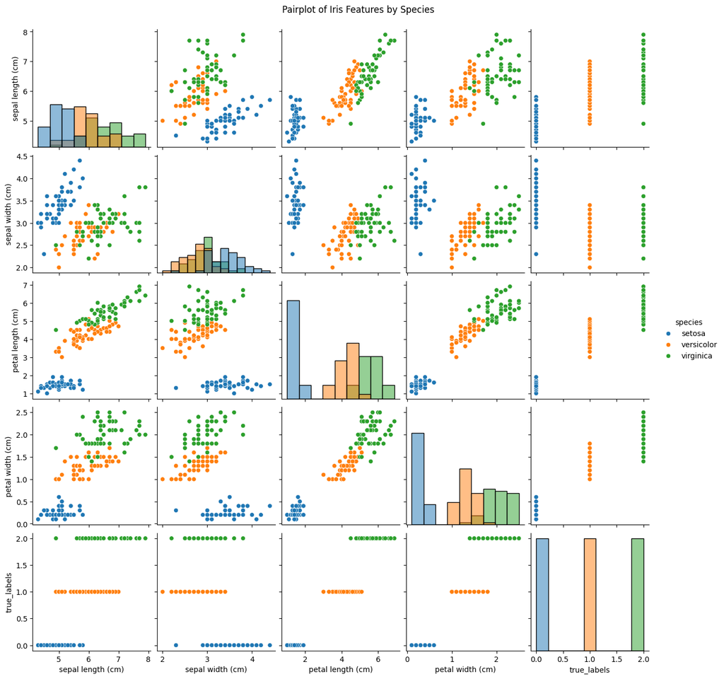

```python
# Pairplot to see relationships between features
sns.pairplot(df, hue='species', diag_kind='hist')
plt.suptitle('Pairplot of Iris Features by Species', y=1.02)
plt.show()
```

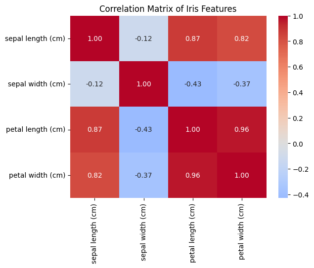

```python
# Correlation matrix
correlation_matrix = df[iris.feature_names].corr()
sns.heatmap(correlation_matrix, annot=True, cmap='coolwarm', center=0, fmt='.2f')
plt.title('Correlation Matrix of Iris Features')
plt.show()
```

### Observation

It seems that petal length and with are very highly correlated, meaning that they could be treated as one dimention.

Sepal width seems to be much less correlated with the petal dimention. It is likely that after the petal dimention, sepal width would be the second decisive factor in the classification.

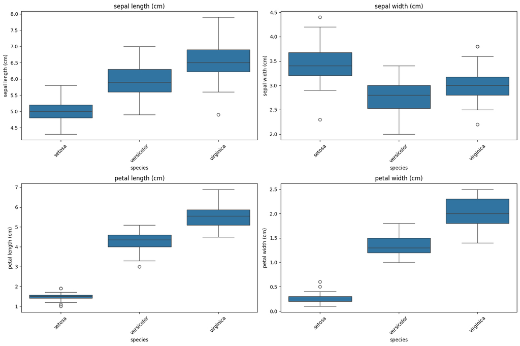

```python
# Boxplots for each feature by species
fig, axes = plt.subplots(2, 2, figsize=(15, 10))
axes = axes.ravel()

for ax, feature in zip(axes, iris.feature_names):
    sns.boxplot(x='species', y=feature, data=df, ax=ax)
    ax.set_title(feature)
    ax.tick_params(axis='x', rotation=45)

plt.tight_layout()
plt.show()
```

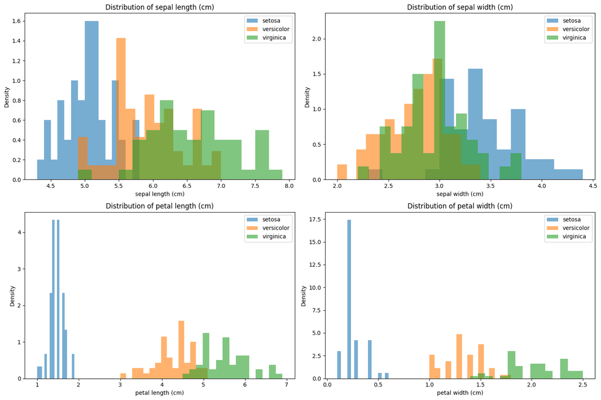

```python
# Distribution plots for each feature
fig, axes = plt.subplots(2, 2, figsize=(15, 10))
axes = axes.ravel()

for ax, feature in zip(axes, iris.feature_names):
    for species in species_names:
        species_data = df[df['species'] == species][feature]
        ax.hist(species_data, alpha=0.6, label=species, bins=15, density=True)
    ax.set_title("Distribution of %s" % feature)
    ax.set_xlabel(feature)
    ax.set_ylabel("Density")
    ax.legend()

plt.tight_layout()
plt.show()
```

### Data Preprocessing

```python
# Scale the numerical features
# This is necessary as the above EDA confirms that the features are well varied in their means and standard deviations
# Scaling the data should make the models less biased
scaler = StandardScaler()
X_scaled = scaler.fit_transform(X)
# There is no need to perform other transformations, such as log transformation, as the data seems to almost follow a normal distribution
# The number of outliers is also negligible
```

### PCA for Dimensionality Reduction and Visualization

```python
# Perform PCA for visualization
pca = PCA(n_components=2)
X_pca = pca.fit_transform(X_scaled)

print("PCA RESULTS:")
print("=" * 50)
print("Explained variance ratio:", pca.explained_variance_ratio_)
print("Total explained variance: %.3f" % sum(pca.explained_variance_ratio_))
```

```
PCA RESULTS:
==================================================
Explained variance ratio: [0.72962445 0.22850762]
Total explained variance: 0.958
```

### Observation

Note that only two dimentions were enough to describe 95.8% of the variance, suggesting that the observations made about the correlation above were correct.

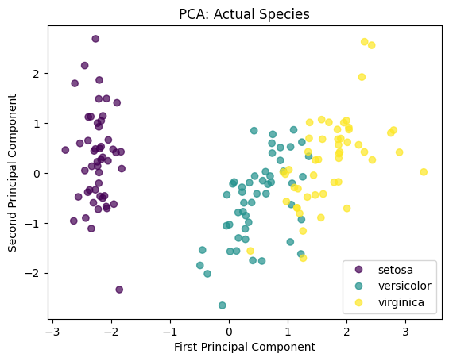

```python
# Visualize PCA results
scatter = plt.scatter(X_pca[:, 0], X_pca[:, 1], c=target, cmap='viridis', alpha=0.7)
plt.xlabel('First Principal Component')
plt.ylabel('Second Principal Component')
plt.title('PCA: Actual Species')
plt.legend(handles=scatter.legend_elements()[0], labels=species_names.tolist())
plt.show()
```

### Observation

Based on this visualisation, it is expected that the model will classify setosa with almost 100% accuracy, while struggling with the versicolor/virginica pair.

### Determine Optimal Number of Clusters

```python
# Function to find best label permutation for accuracy
def label_permute_compare(y_true, y_pred):
    """
    y_true: true labels
    y_pred: predicted cluster labels
    Returns:
    - best_perm: best permutation of labels found
    - best_acc: best accuracy achieved
    - best_y_pred_mapped: predicted labels mapped using best permutation
    """
    unique_labels = np.unique(y_pred)
    best_acc = 0.

    # Generate all possible permutations of the unique labels
    for perm in permutations(unique_labels):
        # Create mapping from original cluster labels to permuted labels
        y_pred_mapped = [perm[label] for label in y_pred]

        accuracy = accuracy_score(y_true, y_pred_mapped)
        if accuracy > best_acc:
            best_acc = accuracy
            best_perm = perm
            best_y_pred_mapped = y_pred_mapped

    return best_perm, best_acc, best_y_pred_mapped
```

```python
# Determine optimal number of clusters using multiple metrics
inertia = []
silhouette_scores_kmeans = []
silhouette_scores_agg = []
accuracy_scores_kmeans = []
accuracy_scores_agg = []
k_range = range(2, 8)

for k in k_range:
    # K-Means
    kmeans = KMeans(n_clusters=k, random_state=42, n_init=10)
    kmeans_labels = kmeans.fit_predict(X_scaled)
    inertia.append(kmeans.inertia_)
    silhouette_scores_kmeans.append(silhouette_score(X_scaled, kmeans_labels))
    accuracy_scores_kmeans.append(label_permute_compare(target, kmeans_labels)[1])

    # Agglomerative Clustering (default parameters)
    agg = AgglomerativeClustering(n_clusters=k)
    agg_labels = agg.fit_predict(X_scaled)
    silhouette_scores_agg.append(silhouette_score(X_scaled, agg_labels))
    accuracy_scores_agg.append(label_permute_compare(target, agg_labels)[1])
```

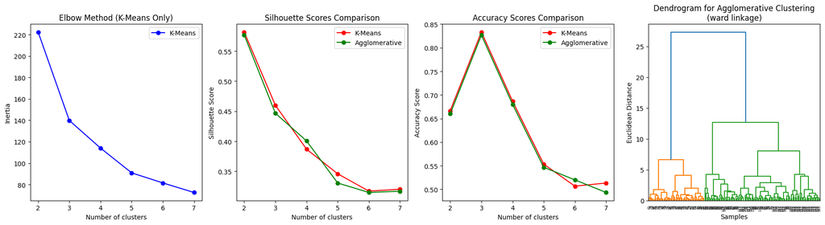

```python
# Plot comparison of methods
plt.figure(figsize=(18, 5))

# Elbow Method
plt.subplot(1, 4, 1)
plt.plot(k_range, inertia, 'bo-', label='K-Means')
plt.xlabel('Number of clusters')
plt.ylabel('Inertia')
plt.title('Elbow Method (K-Means Only)')
plt.legend()

# Silhouette Scores Comparison
plt.subplot(1, 4, 2)
plt.plot(k_range, silhouette_scores_kmeans, 'ro-', label='K-Means')
plt.plot(k_range, silhouette_scores_agg, 'go-', label='Agglomerative')
plt.xlabel('Number of clusters')
plt.ylabel('Silhouette Score')
plt.title('Silhouette Scores Comparison')
plt.legend()

# Accuracy Scores Comparison
plt.subplot(1, 4, 3)
plt.plot(k_range, accuracy_scores_kmeans, 'ro-', label='K-Means')
plt.plot(k_range, accuracy_scores_agg, 'go-', label='Agglomerative')
plt.xlabel('Number of clusters')
plt.ylabel('Accuracy Score')
plt.title('Accuracy Scores Comparison')
plt.legend()

# Dendrogram for Agglomerative Clustering
plt.subplot(1, 4, 4)
dendrogram = sch.dendrogram(sch.linkage(X_scaled, method='ward'))
plt.title('Dendrogram for Agglomerative Clustering\n(ward linkage)')
plt.xlabel('Samples')
plt.ylabel('Euclidean Distance')

plt.tight_layout()
plt.show()
```

### Compare Different Linkage Methods and Metric Parameters

```python
# Define different linkage methods to test
linkage_methods = ('ward', 'complete', 'average', 'single')

# Test different parameter combinations
agg_results = {
    'linkage': [],
    'metric': [],
    'silhouette_score': [],
    'accuracy': [],
    'ari': [],
    'labels': [],
    'mapped_labels': []
}

optimal_clusters = 3

for linkage in linkage_methods:
    for metric in ('euclidean', 'manhattan', 'cosine'):
        # Skip incompatible combinations
        if linkage == 'ward' and metric != 'euclidean':
            continue

        agg = AgglomerativeClustering(n_clusters=optimal_clusters, linkage=linkage, metric=metric)
        agg_labels = agg.fit_predict(X_scaled)

        # Calculate metrics
        silhouette = silhouette_score(X_scaled, agg_labels)
        _, accuracy, mapped_labels = label_permute_compare(target, agg_labels)
        ari = adjusted_rand_score(target, agg_labels)

        agg_results['linkage'].append(linkage)
        agg_results['metric'].append(metric)
        agg_results['silhouette_score'].append(silhouette)
        agg_results['accuracy'].append(accuracy)
        agg_results['ari'].append(ari)
        agg_results['labels'].append(agg_labels)
        agg_results['mapped_labels'].append(mapped_labels)

# Convert results to DataFrame, sorted by accuracy (descending)
agg_comparison_df = pd.DataFrame(agg_results).sort_values('accuracy', ascending=False)

print("AGGLOMERATIVE CLUSTERING PARAMETER COMPARISON:")
print("=" * 60)
print(agg_comparison_df.iloc[:,:5].round(4))
```

```
AGGLOMERATIVE CLUSTERING PARAMETER COMPARISON:
============================================================
    linkage     metric  silhouette_score  accuracy     ari
5   average  manhattan            0.4530    0.8867  0.7184
3  complete     cosine            0.4466    0.8400  0.6335
0      ward  euclidean            0.4467    0.8267  0.6153
2  complete  manhattan            0.4350    0.8200  0.6146
6   average     cosine            0.4302    0.8200  0.6097
1  complete  euclidean            0.4496    0.7867  0.5726
4   average  euclidean            0.4803    0.6867  0.5621
8    single  manhattan            0.4949    0.6800  0.5638
9    single     cosine            0.0956    0.6667  0.5414
7    single  euclidean            0.5046    0.6600  0.5584
```

### Visualize Performance of Different Parameter Combinations

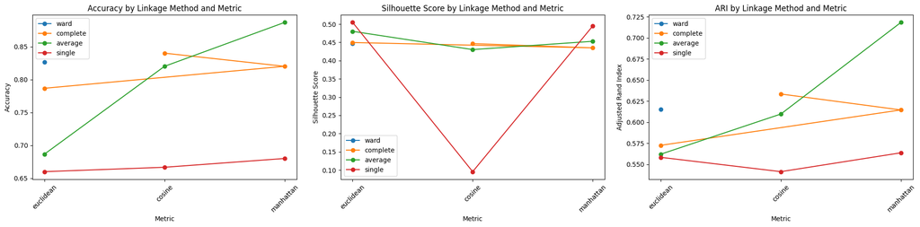

```python
# Plot comparison of different parameter combinations
plt.figure(figsize=(20, 5))

# Accuracy comparison
plt.subplot(1, 3, 1)
for linkage in linkage_methods:
    linkage_data = agg_comparison_df[agg_comparison_df['linkage'] == linkage]
    if not linkage_data.empty:
        plt.plot(linkage_data['metric'], linkage_data['accuracy'], 'o-', label=linkage)
plt.xlabel('Metric')
plt.ylabel('Accuracy')
plt.title('Accuracy by Linkage Method and Metric')
plt.legend()
plt.xticks(rotation=45)

# Silhouette score comparison
plt.subplot(1, 3, 2)
for linkage in linkage_methods:
    linkage_data = agg_comparison_df[agg_comparison_df['linkage'] == linkage]
    if not linkage_data.empty:
        plt.plot(linkage_data['metric'], linkage_data['silhouette_score'], 'o-', label=linkage)
plt.xlabel('Metric')
plt.ylabel('Silhouette Score')
plt.title('Silhouette Score by Linkage Method and Metric')
plt.legend()
plt.xticks(rotation=45)

# ARI comparison
plt.subplot(1, 3, 3)
for linkage in linkage_methods:
    linkage_data = agg_comparison_df[agg_comparison_df['linkage'] == linkage]
    if not linkage_data.empty:
        plt.plot(linkage_data['metric'], linkage_data['ari'], 'o-', label=linkage)
plt.xlabel('Metric')
plt.ylabel('Adjusted Rand Index')
plt.title('ARI by Linkage Method and Metric')
plt.legend()
plt.xticks(rotation=45)

plt.tight_layout()
plt.show()
```

### Dendrograms for Comparison

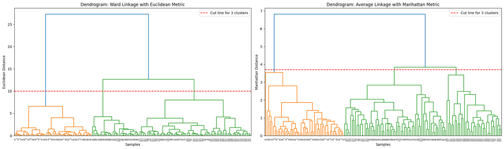

```python
# Create side-by-side dendrograms for comparison
plt.figure(figsize=(20, 6))

# First dendrogram (ward linkage with Euclidean distance)
plt.subplot(1, 2, 1)
dendrogram1 = sch.dendrogram(sch.linkage(X_scaled, method='ward', metric='euclidean'))
plt.title('Dendrogram: Ward Linkage with Euclidean Metric')
plt.xlabel('Samples')
plt.ylabel('Euclidean Distance')
plt.axhline(y=10, color='r', linestyle='--', label='Cut line for 3 clusters')
plt.legend()

# Second dendrogram (best parameters)
plt.subplot(1, 2, 2)
dendrogram2 = sch.dendrogram(sch.linkage(X_scaled, method="average", metric="cityblock"))
plt.title('Dendrogram: Average Linkage with Manhattan Metric')
plt.xlabel('Samples')
plt.ylabel('Manhattan Distance')
plt.axhline(y=3.7, color='r', linestyle='--', label='Cut line for 3 clusters')
plt.legend()

plt.tight_layout()
plt.show()
```

### Apply Both Clustering Algorithms with Best Parameters

```python
# Apply both clustering algorithms with optimal clusters (3)
optimal_clusters = 3

# K-Means
kmeans = KMeans(n_clusters=optimal_clusters, random_state=42, n_init=10)
kmeans_labels = kmeans.fit_predict(X_scaled)

# Agglomerative Clustering with best parameters
best_linkage = "average"
best_metric = "manhattan"
agg_best = AgglomerativeClustering(n_clusters=optimal_clusters,
                                   linkage=best_linkage,
                                   metric=best_metric)
agg_labels_best = agg_best.fit_predict(X_scaled)

# Also keep default agglomerative for comparison
agg_default = AgglomerativeClustering(n_clusters=optimal_clusters)
agg_labels_default = agg_default.fit_predict(X_scaled)

print("Cluster distributions:")
print("K-Means:", np.bincount(kmeans_labels))
print("Agglomerative (default):", np.bincount(agg_labels_default))
print("Agglomerative (best):", np.bincount(agg_labels_best))
```

```
Cluster distributions:
K-Means: [53 50 47]
Agglomerative (default): [71 49 30]
Agglomerative (best): [50 35 65]
```

### Map Clusters to True Labels for Accuracy Calculation

```python
# Find best label mappings using permutation method
_, kmeans_accuracy, kmeans_mapped = label_permute_compare(target, kmeans_labels)
_, agg_accuracy_default, agg_mapped_default = label_permute_compare(target, agg_labels_default)
_, agg_accuracy_best, agg_mapped_best = label_permute_compare(target, agg_labels_best)

# Add mapped labels to dataframe

print("Accuracy scores:")
print("K-Means = %.1f%%" % (100 * kmeans_accuracy))
print("Agglomerative (default) = %.1f%%" % (100 * agg_accuracy_default))
print("Agglomerative (best) = %.1f%%" % (100 * agg_accuracy_best))
```

```
Accuracy scores:
K-Means = 83.3%
Agglomerative (default) = 82.7%
Agglomerative (best) = 88.7%
```

### Calculate Performance Metrics

```python
# Calculate performance metrics for all methods
kmeans_silhouette = silhouette_score(X_scaled, kmeans_labels)
agg_silhouette_default = silhouette_score(X_scaled, agg_labels_default)
agg_silhouette_best = silhouette_score(X_scaled, agg_labels_best)

kmeans_ari = adjusted_rand_score(target, kmeans_labels)
agg_ari_default = adjusted_rand_score(target, agg_labels_default)
agg_ari_best = adjusted_rand_score(target, agg_labels_best)

# Create confusion matrices
kmeans_cm = confusion_matrix(target, kmeans_mapped)
agg_cm_default = confusion_matrix(target, agg_mapped_default)
agg_cm_best = confusion_matrix(target, agg_mapped_best)

# Create comparison table
comparison_df = pd.DataFrame({
    'Algorithm': ['K-Means', 'Agglomerative (default)', 'Agglomerative (best)'],
    'Accuracy': [kmeans_accuracy, agg_accuracy_default, agg_accuracy_best],
    'Silhouette Score': [kmeans_silhouette, agg_silhouette_default, agg_silhouette_best],
    'Adjusted Rand Index': [kmeans_ari, agg_ari_default, agg_ari_best],
})

print("PERFORMANCE COMPARISON:")
print("=" * 60)
print(comparison_df.round(4))
```

```
PERFORMANCE COMPARISON:
============================================================
                 Algorithm  Accuracy  Silhouette Score  Adjusted Rand Index
0                  K-Means    0.8333            0.4599               0.6201
1  Agglomerative (default)    0.8267            0.4467               0.6153
2     Agglomerative (best)    0.8867            0.4530               0.7184
```

### Visualize Confusion Matrices

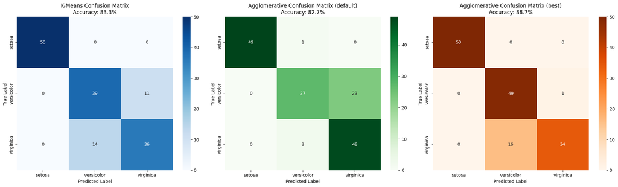

```python
# Plot confusion matrices
plt.figure(figsize=(20, 6))

# K-Means Confusion Matrix
plt.subplot(1, 3, 1)
sns.heatmap(kmeans_cm, annot=True, fmt='d', cmap='Blues',
            xticklabels=species_names, yticklabels=species_names)
plt.title('K-Means Confusion Matrix\nAccuracy: %.1f%%' % (100 * kmeans_accuracy))
plt.xlabel('Predicted Label')
plt.ylabel('True Label')

# Agglomerative Confusion Matrix (default)
plt.subplot(1, 3, 2)
sns.heatmap(agg_cm_default, annot=True, fmt='d', cmap='Greens',
            xticklabels=species_names, yticklabels=species_names)
plt.title('Agglomerative Confusion Matrix (default)\nAccuracy: %.1f%%' % (100 * agg_accuracy_default))
plt.xlabel('Predicted Label')
plt.ylabel('True Label')

# Agglomerative Confusion Matrix (best)
plt.subplot(1, 3, 3)
sns.heatmap(agg_cm_best, annot=True, fmt='d', cmap='Oranges',
            xticklabels=species_names, yticklabels=species_names)
plt.title('Agglomerative Confusion Matrix (best)\nAccuracy: %.1f%%' % (100 * agg_accuracy_best))
plt.xlabel('Predicted Label')
plt.ylabel('True Label')

plt.tight_layout()
plt.show()
```

### Visualize the Results

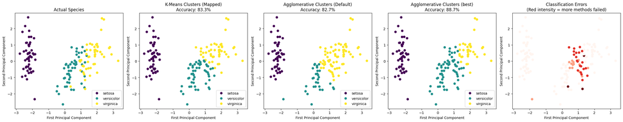

```python
# Create comparison visualization
plt.figure(figsize=(25, 5))

# Actual species
plt.subplot(1, 5, 1)
scatter = plt.scatter(X_pca[:, 0], X_pca[:, 1], c=target, cmap='viridis')
plt.xlabel('First Principal Component')
plt.ylabel('Second Principal Component')
plt.title('Actual Species')
plt.legend(handles=scatter.legend_elements()[0], labels=species_names.tolist())

# K-Means clusters (mapped)
plt.subplot(1, 5, 2)
scatter = plt.scatter(X_pca[:, 0], X_pca[:, 1], c=kmeans_mapped, cmap='viridis')
plt.xlabel('First Principal Component')
plt.ylabel('Second Principal Component')
plt.title('K-Means Clusters (Mapped)\nAccuracy: %.1f%%' % (100 * kmeans_accuracy))
plt.legend(handles=scatter.legend_elements()[0], labels=species_names.tolist())

# Agglomerative clusters default (mapped)
plt.subplot(1, 5, 3)
scatter = plt.scatter(X_pca[:, 0], X_pca[:, 1], c=agg_mapped_default, cmap='viridis')
plt.xlabel('First Principal Component')
plt.ylabel('Second Principal Component')
plt.title('Agglomerative Clusters (Default)\nAccuracy: %.1f%%' % (100 * agg_accuracy_default))
plt.legend(handles=scatter.legend_elements()[0], labels=species_names.tolist())

# Agglomerative clusters best (mapped)
plt.subplot(1, 5, 4)
scatter = plt.scatter(X_pca[:, 0], X_pca[:, 1], c=agg_mapped_best, cmap='viridis')
plt.xlabel('First Principal Component')
plt.ylabel('Second Principal Component')
plt.title('Agglomerative Clusters (best)\nAccuracy: %.1f%%' % (100 * agg_accuracy_best))
plt.legend(handles=scatter.legend_elements()[0], labels=species_names.tolist())

# Error comparison
plt.subplot(1, 5, 5)
kmeans_errors = (target != kmeans_mapped).astype(int)
agg_default_errors = (target != agg_mapped_default).astype(int)
agg_best_errors = (target != agg_mapped_best).astype(int)
plt.scatter(X_pca[:, 0], X_pca[:, 1], c=kmeans_errors + agg_default_errors + agg_best_errors, cmap='Reds')
plt.xlabel('First Principal Component')
plt.ylabel('Second Principal Component')
plt.title('Classification Errors\n(Red intensity = more methods failed)')

plt.tight_layout()
plt.show()
```

### Detailed Error Analysis

```python
# Detailed error analysis
print("DETAILED ERROR ANALYSIS:")
print("=" * 60)

for method, mapped_labels, accuracy in (
    ('K-Means', kmeans_mapped, kmeans_accuracy),
    ('Agglomerative (default)', agg_mapped_default, agg_accuracy_default),
    ('Agglomerative (best)', agg_mapped_best, agg_accuracy_best),
):
    errors = target != mapped_labels
    error_indices = np.where(errors)[0]

    print("%s:" % method)
    print("  Accuracy: %.1f%%" % (accuracy * 100))
    print("  Total errors: %2d/%3d errors (%.1f%%)" % (np.sum(errors), len(errors), np.mean(errors) * 100))

    if len(error_indices) > 0:
        error_samples = df.iloc[error_indices]
        print("  Error breakdown by species:")
        for species in species_names:
            species_errors = error_samples[error_samples['species'] == species]
            total_species = np.sum(target == np.where(species_names == species)[0][0])
            if len(species_errors) > 0:
                print("    %s: %2d/%2d  errors (%4.1f%%)" % (species.ljust(10), len(species_errors), total_species, len(species_errors)/total_species*100))
    print()
```

```
DETAILED ERROR ANALYSIS:
============================================================
K-Means:
  Accuracy: 83.3%
  Total errors: 25/150 errors (16.7%)
  Error breakdown by species:
    versicolor: 11/50  errors (22.0%)
    virginica : 14/50  errors (28.0%)

Agglomerative (default):
  Accuracy: 82.7%
  Total errors: 26/150 errors (17.3%)
  Error breakdown by species:
    setosa    :  1/50  errors ( 2.0%)
    versicolor: 23/50  errors (46.0%)
    virginica :  2/50  errors ( 4.0%)

Agglomerative (best):
  Accuracy: 88.7%
  Total errors: 17/150 errors (11.3%)
  Error breakdown by species:
    versicolor:  1/50  errors ( 2.0%)
    virginica : 16/50  errors (32.0%)
```

## Discussion and Interpretation

Based on the comprehensive analysis with different linkage methods and metric parameters:

### Species-Specific Insights:

Iris setosa was classified with near-perfect accuracy across all methods due to its distinct morphological features. The main challenge remains distinguishing between versicolor and virginica species, which are not linearly separable.

### Key Findings:

1. **Parameter Sensitivity**: Agglomerative Clustering performance varies significantly with different parameter combinations
2. **Best Parameters**: The combination of Average linkage with Manhattan metric achieved the highest accuracy of 88.7%
3. **Performance Improvement**: Optimized parameters improved Agglomerative Clustering accuracy from 82.7% to 88.7%
4. **Confusion Matrix Balance**: K-Means had a much more balanced confusion matrix, with the errors among versicolor and virginica split almost equally, whereas both Agglomerative Clustering methods had a bias towards one of them over the other

### Practical Implications:

- Parameter tuning is crucial for Agglomerative Clustering performance
- Different linkage methods capture different cluster structures
- The optimal parameter combination may vary across different datasets

This poses a problem when using Agglomerative Clustering for such types of tasks, as in cases where the labels are not readily available, it would be difficult to check which parameters perform best for the current task.

Furthermore, the fact that even with parameter tuning the confusion matrix of Agglomerative Clustering was still biased (but to the opposite group) suggests an inherent instability in the method. Given a few different datapoints, the balance in the middle group in the hierarchy could tip again, completely changing the composition of the clusters and potentially harming accuracy alot.

Given this analysis, I would suggest that practical applications on tasks very similar to this one to use K-Means Clustering instead of Agglomerative Clustering, even though the above accuracy values might suggest otherwise.

### Limitations and Future Work:

**Current Limitations:**

- Limited to Iris dataset characteristics
- Did not perform deep parameter optimization on K-Means Clustering

**Future Directions:**

- Extend analysis to other clustering variants
- Incorporate additional validation metrics
- Apply to larger, more complex botanical datasets